# hospital readmissions project

Meelad

02 2019

```r
setwd("/Users/meela/OneDrive/Documents/R/R working directory files/Stats project")
library(stats)
library(ggplot2)
library(corrplot)
library(pwr)
library(pscl)
library(car)
library(rlang)
library(dplyr)
library(forcats)
```

# Datasets below:

Original dataset: diabetic diab: filtered dataset (untouched) diab2: working filtered dataset

```
##   encounter_id        patient_nbr                     race
##  Min.   :    12522   Min.   :      135   AfricanAmerican:12887
##  1st Qu.: 81458068   1st Qu.: 23375768   Asian          :  497
##  Median :144057399   Median : 48166798   Caucasian      :53491
##  Mean   :156815588   Mean   : 55051604   Hispanic       : 1517
##  3rd Qu.:215551324   3rd Qu.: 87522217   Other          : 1178
##  Max.   :443867222   Max.   :189502619   NA's           : 1948
##
##              gender           age              weight
##  Female         :38025   [70-80):18210   [75-100) : 1195
##  Male           :33490   [60-70):15960   [50-75)  :  781
##  Unknown/Invalid:    3   [50-60):12466   [100-125):  566
##                          [80-90):11589   [125-150):  131
##                          [40-50): 6878   [25-50)  :   89
##                          [30-40): 2699   (Other)  :   91
##                          (Other): 3716   NA's     :68665
##  admission_type_id discharge_disposition_id admission_source_id
##  Min.   :1.0       Min.   : 1.000           Min.   : 1.000
##  1st Qu.:1.0       1st Qu.: 1.000           1st Qu.: 1.000
##  Median :1.0       Median : 1.000           Median : 7.000
##  Mean   :2.1       Mean   : 3.593           Mean   : 5.657
##  3rd Qu.:3.0       3rd Qu.: 3.000           3rd Qu.: 7.000
##  Max.   :8.0       Max.   :28.000           Max.   :25.000
##
##  time_in_hospital   payer_code                 medical_specialty
##  Min.   : 1.000   MC     :20414   InternalMedicine      :10919
##  1st Qu.: 2.000   HM     : 4022   Family/GeneralPractice: 5118
##  Median : 3.000   BC     : 3432   Emergency/Trauma      : 4465
##  Mean   : 4.289   SP     : 3347   Cardiology            : 4266
##  3rd Qu.: 6.000   MD     : 2197   Surgery-General       : 2221
##  Max.   :14.000   (Other): 7063   (Other)               :10052
##                   NA's   :31043   NA's                  :34477
##  num_lab_procedures num_procedures  num_medications number_outpatient
##  Min.   :  1.00     Min.   :0.000   Min.   : 1.00   Min.   : 0.0000
##  1st Qu.: 31.00     1st Qu.:0.000   1st Qu.:10.00   1st Qu.: 0.0000
##  Median : 44.00     Median :1.000   Median :14.00   Median : 0.0000
##  Mean   : 43.08     Mean   :1.431   Mean   :15.71   Mean   : 0.2801
##  3rd Qu.: 57.00     3rd Qu.:2.000   3rd Qu.:20.00   3rd Qu.: 0.0000
##  Max.   :132.00     Max.   :6.000   Max.   :81.00   Max.   :42.0000
##
```

[output cut: 57 more lines]

```
##  No    :71518             No    :71516            No    :71517
##  Steady:    0             Steady:    2            Steady:    1
##
##
##
##
##
##  change     diabetesMed readmitted
##  Ch:32024   No :17199   <30: 6293
##  No:39494   Yes:54319   >30:22240
##                         NO :42985
##
##
##
##
```

# Data Cleaning

```r
colnames(diab2)
```

```
##  [1] "encounter_id"             "patient_nbr"
##  [3] "race"                     "gender"
##  [5] "age"                      "weight"
##  [7] "admission_type_id"        "discharge_disposition_id"
##  [9] "admission_source_id"      "time_in_hospital"
## [11] "payer_code"               "medical_specialty"
## [13] "num_lab_procedures"       "num_procedures"
## [15] "num_medications"          "number_outpatient"
## [17] "number_emergency"         "number_inpatient"
## [19] "diag_1"                   "diag_2"
## [21] "diag_3"                   "number_diagnoses"
## [23] "max_glu_serum"            "A1Cresult"
## [25] "metformin"                "repaglinide"
## [27] "nateglinide"              "chlorpropamide"
## [29] "glimepiride"              "acetohexamide"
## [31] "glipizide"                "glyburide"
## [33] "tolbutamide"              "pioglitazone"
## [35] "rosiglitazone"            "acarbose"
## [37] "miglitol"                 "troglitazone"
## [39] "tolazamide"               "examide"
## [41] "citoglipton"              "insulin"
## [43] "glyburide.metformin"      "glipizide.metformin"
## [45] "glimepiride.pioglitazone" "metformin.rosiglitazone"
## [47] "metformin.pioglitazone"   "change"
## [49] "diabetesMed"              "readmitted"
```

```r
# remove columns that will be omitted for the purposes of this project
```

```r
# remove columns that will be omitted for the purposes of this project
diab2 <- subset(diab2, select= -c(encounter_id, patient_nbr, weight, payer_code, diabetesMed, diag_1, diag_2, diag_3, max_glu_serum, metformin, repaglinide, nateglinide, chlorpropamide, glimepiride, acetohexamide, glipizide, glyburide, tolbutamide, pioglitazone, rosiglitazone,acarbose, miglitol, troglitazone, tolazamide, examide, citoglipton, glyburide.metformin, glipizide.metformin, glimepiride.pioglitazone, metformin.rosiglitazone, metformin.pioglitazone))

colnames(diab2)
```

```
##  [1] "race"                     "gender"
##  [3] "age"                      "admission_type_id"
##  [5] "discharge_disposition_id" "admission_source_id"
##  [7] "time_in_hospital"         "medical_specialty"
##  [9] "num_lab_procedures"       "num_procedures"
## [11] "num_medications"          "number_outpatient"
## [13] "number_emergency"         "number_inpatient"
## [15] "number_diagnoses"         "A1Cresult"
## [17] "insulin"                  "change"
## [19] "readmitted"
```

Use of the following medical specialties: Cardiology, Emergency/Trauma, InternalMedicine/GeneralPractice, Surgery, and the rest is Other

```
##       Cardiology Emergency/Trauma InternalMedicine          Surgery
##             4266             4465            16037             4805
##            Other
##            41945
```

```
##  [1] "race"                     "gender"
##  [3] "age"                      "admission_type_id"
##  [5] "discharge_disposition_id" "admission_source_id"
##  [7] "time_in_hospital"         "num_lab_procedures"
##  [9] "num_procedures"           "num_medications"
## [11] "number_outpatient"        "number_emergency"
## [13] "number_inpatient"         "number_diagnoses"
## [15] "A1Cresult"                "insulin"
## [17] "change"                   "readmitted"
## [19] "new_med_spec2"
```

Cleaning admission type IDs

```
## Emergency    Urgent  Elective      NA's
##     36490     13028     13917      8083
```

# Cleaning discharge disposition id

Group similar disposition ids together: Discharged home 1,6, 8 Outside facility 2,3,4,5,9,10,12, 15,16,17,22-24,27-30 Expired 11,19,20,21 Hospice 13,14 NA 7,9,18,25,26 (includes AMA-against medical advisement-#7, and admitted Inpatient #9 because there were so few)

```
##   dch   exp  hspc  dcho  NA's
## 52679  1084   461 13633  3661
```

# Releveling factor variables that will remain in dataset.

For this project, all drugs except insulin will be dropped. ICD9 codes will be dropped for this project. max_glu_serum will be dropped (95% of observations did not measure max glucose serum levels) Weight will be dropped (too many missing values)

```
##   [0-10)  [10-20)  [20-30)  [30-40)  [40-50)  [50-60)  [60-70)  [70-80)
##      154      535     1127     2699     6878    12466    15960    18210
##  [80-90) [90-100)
##    11589     1900
```

```
##    NO   >30   <30
## 42985 22240  6293
```

```
##  Norm    >7    >8  NA's
##  3791  2891  6304 58532
```

```
##   Down Steady     Up   NA's
##   7505  22129   6963  34921
```

```
##    No    Ch
## 39494 32024
```

```
##    No   Yes
## 17199 54319
```

```
## Female   Male   NA's
##  38025  33490      3
```

```
##    NO   >30   <30
## 42985 22240  6293
```

```
##    NO   <30
## 65225  6293
```

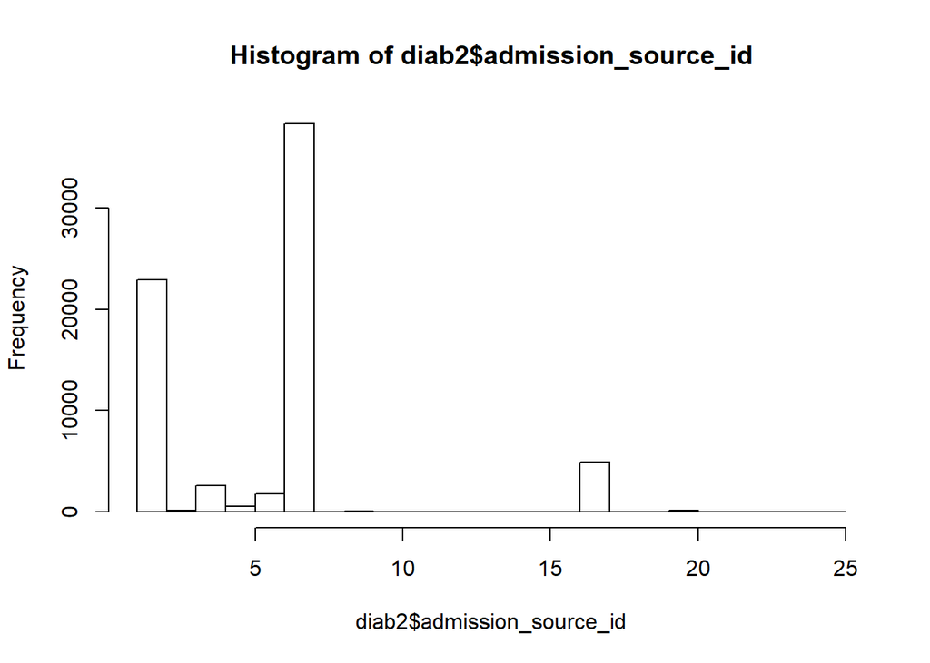

```r
# admission source IDs
hist(diab2$admission_source_id)
```

```r
# keep 1,7,17 : Physician referral, emergency room
diab2$admission_source_id <- ifelse(diab$admission_source_id == 1 |
                                      diab$admission_source_id == 7,
                                    diab2$admission_source_id, NA)

labels_adm_ids = c("physician referral","emergency room")
diab2$admission_source_id <- factor(diab2$admission_source_id, ordered = FALSE, labels = labels_adm_ids)
summary(diab2$admission_source_id)
```

```
## physician referral     emergency room               NA's
##              22007              38290              11221
```

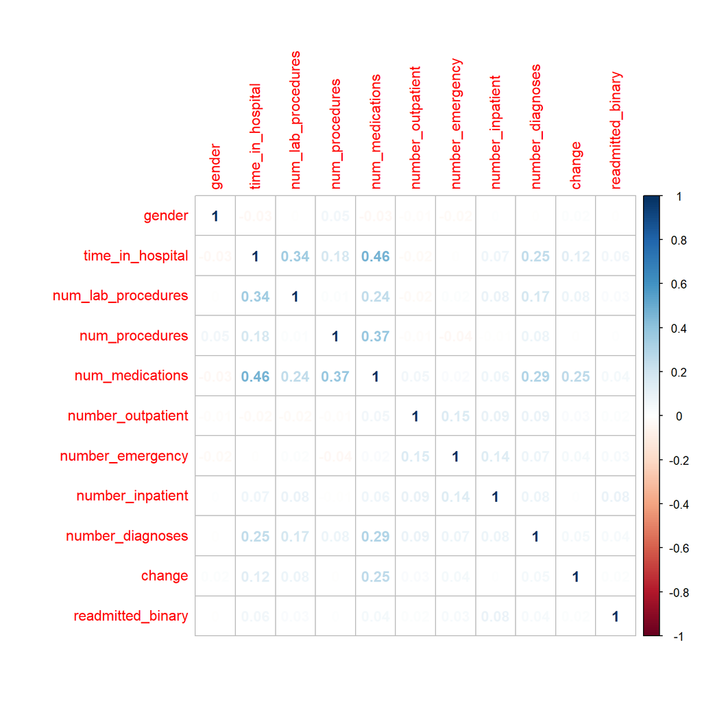

```r
diabcors <- subset(diab2, select= -c(race, age, admission_type_id, discharge_disposition_id, admission_source_id, readmitted, A1Cresult, insulin, new_med_spec2, diabetesMed))


diabcors$gender <- as.numeric(diabcors$gender )
diabcors$change <- as.numeric(diabcors$change)
# diabcors$diabetesMed <- as.numeric(diabcors$diabetesMed)
diabcors$readmitted_binary <- as.numeric(diabcors$readmitted_binary)

cor <- cor(diabcors, method = "spearman", use="pairwise.complete.obs")
corrplot(cor, method="number")
```

# remove colinear variables

```r
# A1Cresult is removed because it has lots of NA values
diab2 <- subset(diab2, select = -c(diabetesMed, insulin, A1Cresult))
```

# Part 1

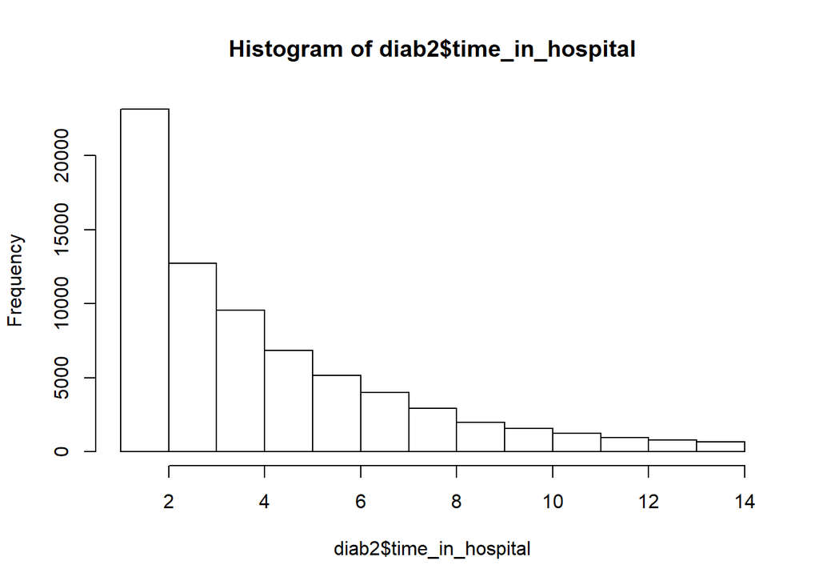

```r
hist(diab2$time_in_hospital)
```

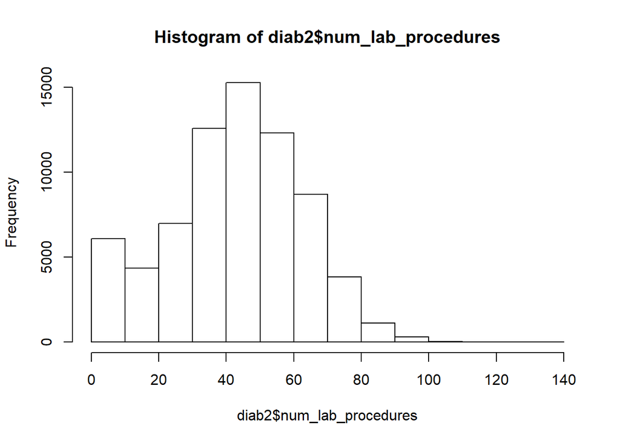

```r
hist(diab2$num_lab_procedures)
```

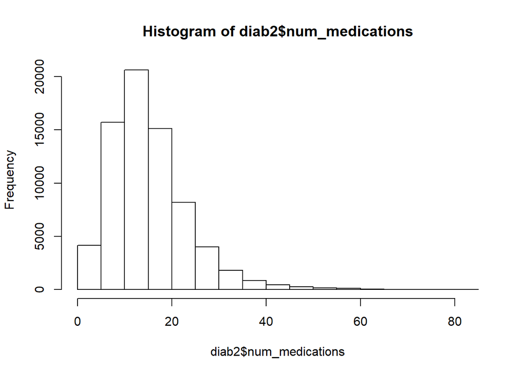

```r
hist(diab2$num_medications)
```

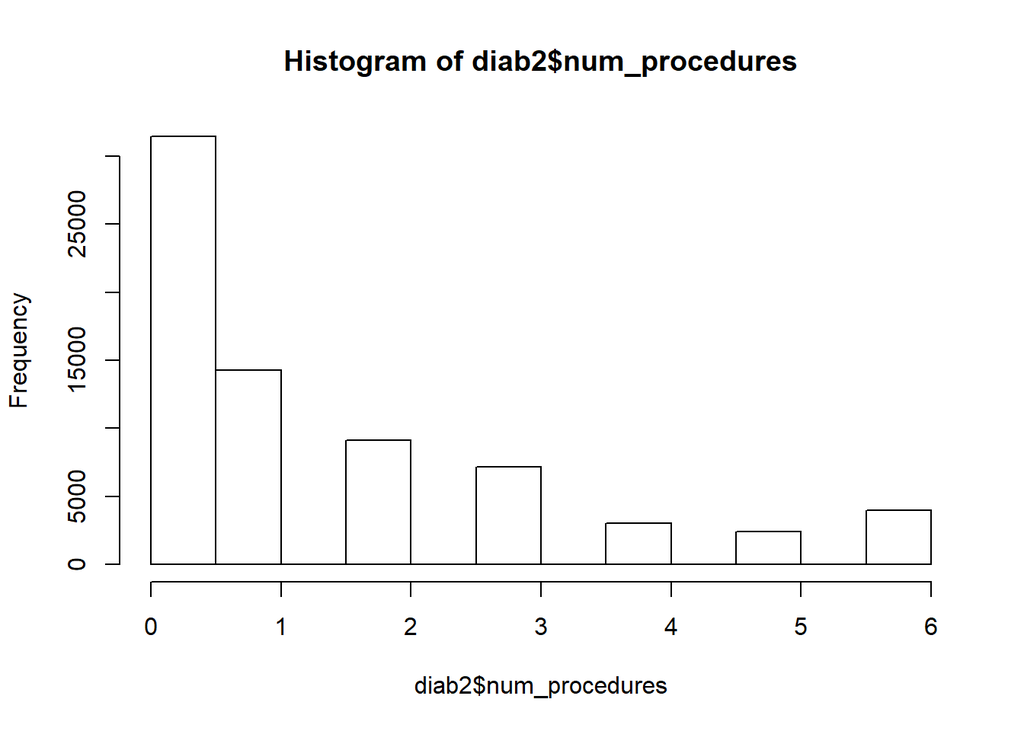

```r
hist(diab2$num_procedures)
```

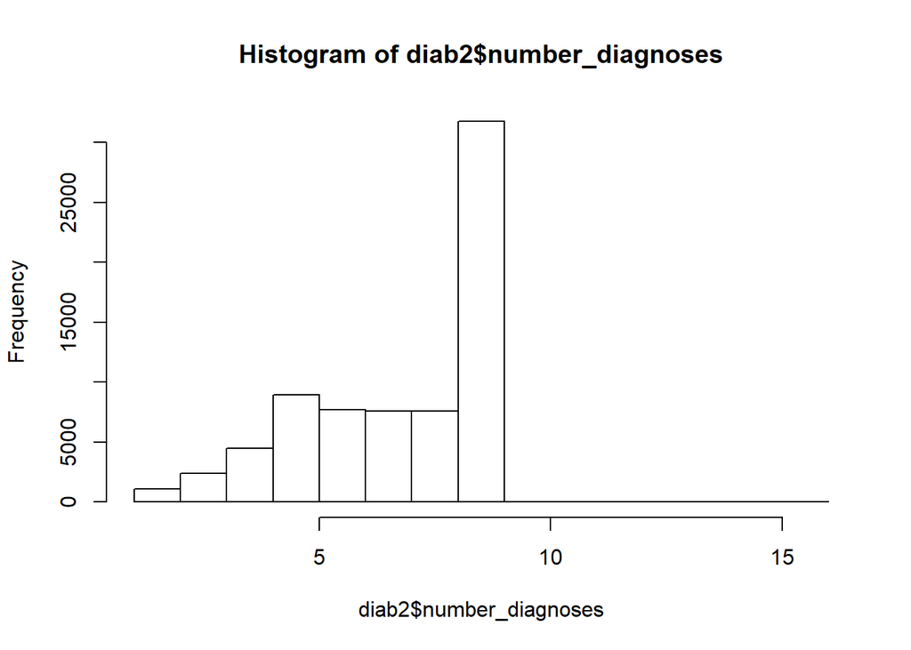

```r
hist(diab2$number_diagnoses)
```

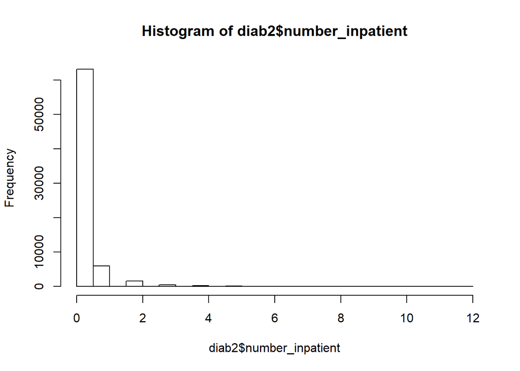

```r
hist(diab2$number_inpatient)
```

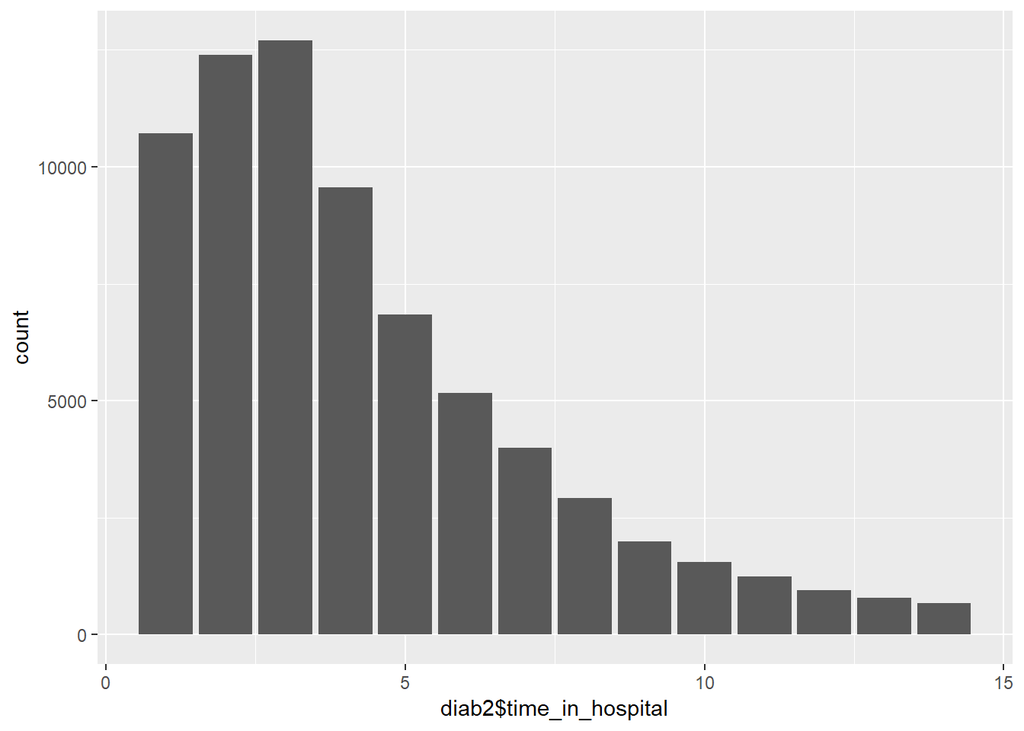

```r
g <- ggplot(data=diab2)

g + geom_bar(aes(x=diab2$time_in_hospital))
```

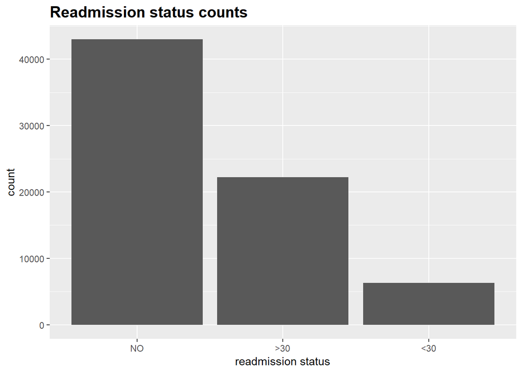

```r
g + geom_bar( aes(x=diab2$readmitted)) +
  xlab("readmission status") +
  ggtitle("Readmission status counts") +
  theme(plot.title = element_text(size = 15, face = "bold"))
```

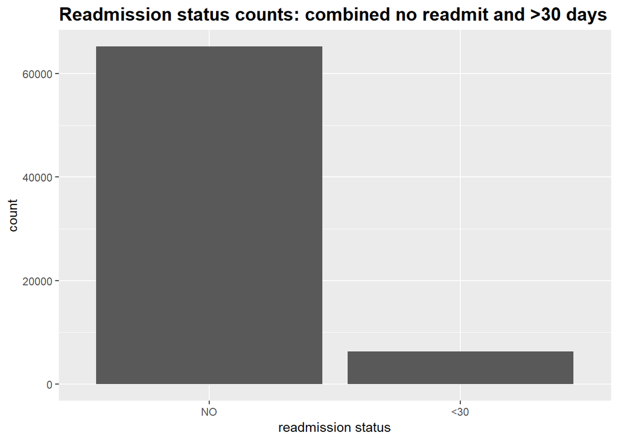

```r
g + geom_bar(aes(x=diab2$readmitted_binary)) +
  xlab("readmission status") +
  ggtitle("Readmission status counts: combined no readmit and >30 days") +
  theme(plot.title = element_text(size = 15, face = "bold"))
```

# visualizing the dataset # Part 2

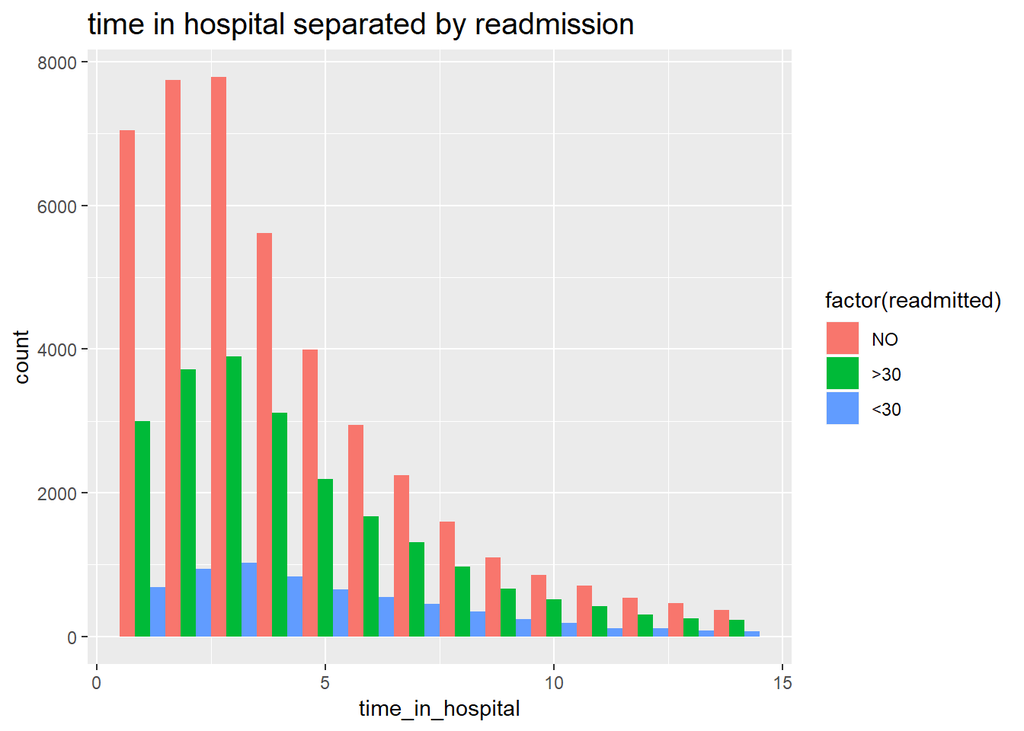

```r
g + geom_histogram(aes(x=time_in_hospital, fill=factor(readmitted)),binwidth=1, position = "dodge") +
  ggtitle("time in hospital separated by readmission")+
  theme(plot.title = element_text(size = 15))
```

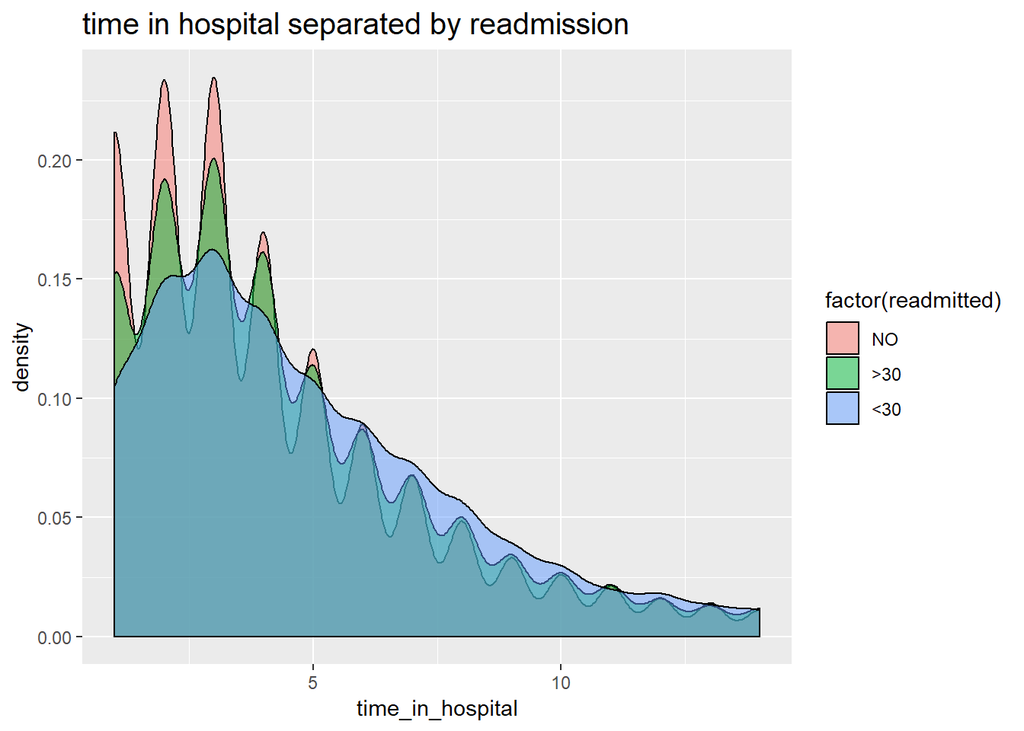

```r
g + geom_density(aes(x=time_in_hospital, fill=factor(readmitted)), alpha=.5) +
  ggtitle("time in hospital separated by readmission")+
  theme(plot.title = element_text(size = 15))
```

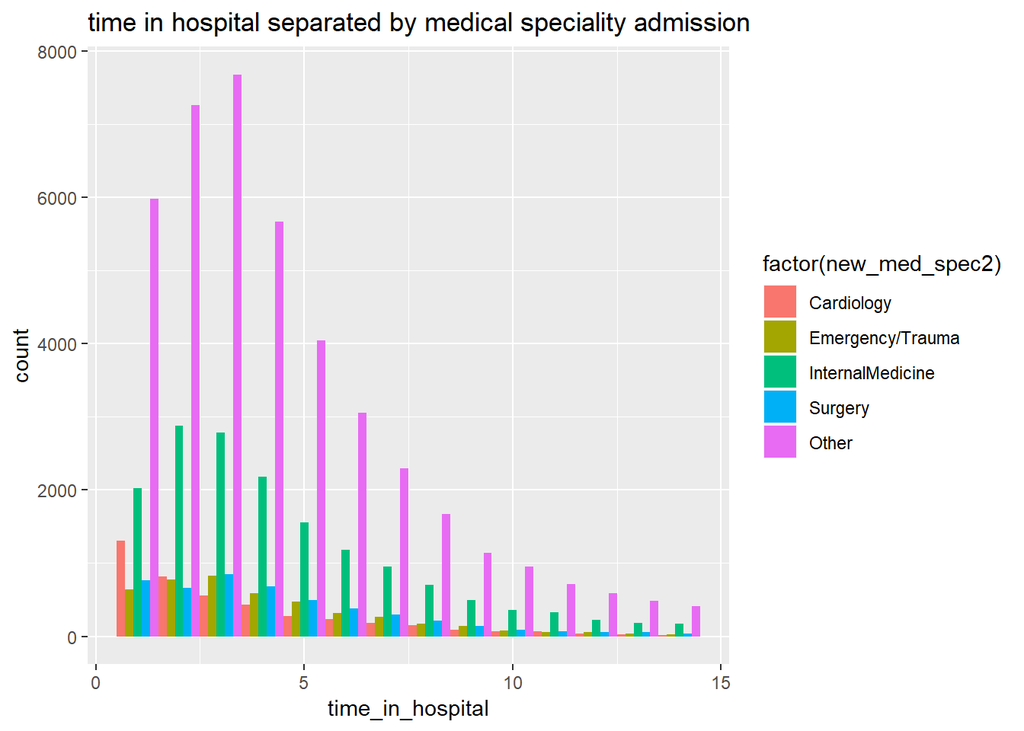

```r
g + geom_histogram(aes(x=time_in_hospital, fill=factor(new_med_spec2)),binwidth=1, position = "dodge") +
  ggtitle("time in hospital separated by medical speciality admission")
```

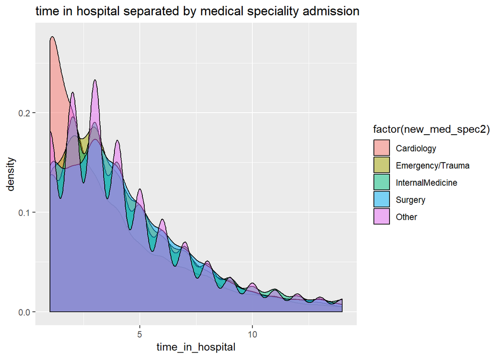

```r
g + geom_density(aes(x=time_in_hospital, fill=factor(new_med_spec2)), alpha = 0.5) +
  ggtitle("time in hospital separated by medical speciality admission")
```

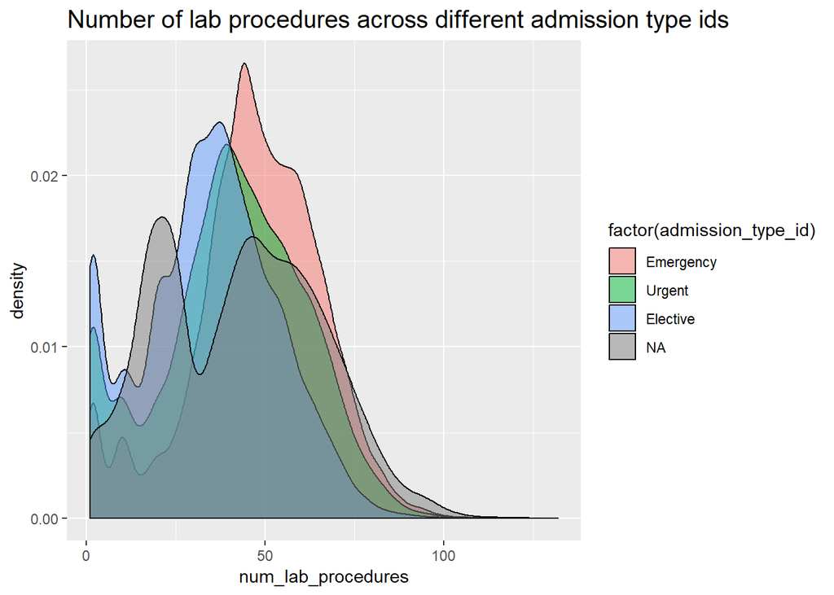

```r
g + geom_density(aes(x=num_lab_procedures, fill=factor(admission_type_id)), alpha=.5) +
  ggtitle("Number of lab procedures across different admission type ids")+
  theme(plot.title = element_text(size = 15))
```

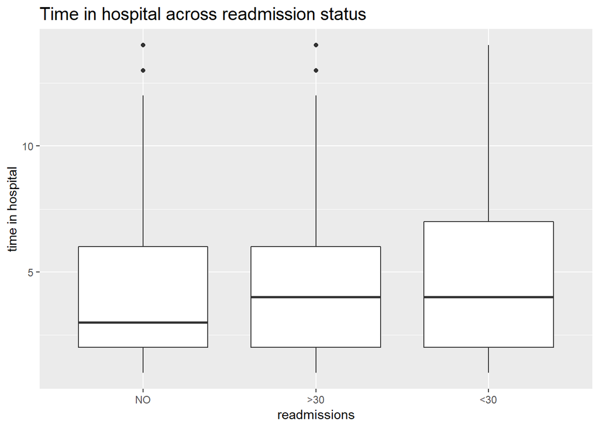

```r
# time in hospital vs readmissions
gReadmit_timeInHosp <- ggplot(data = diab2, aes(x= readmitted, y= time_in_hospital)) +
  geom_boxplot() +
  ggtitle("Time in hospital across readmission status") +
  xlab("readmissions") + ylab("time in hospital")+
  theme(plot.title = element_text(size = 15))
gReadmit_timeInHosp
```